# Part 5 Descriptive statistics

Master thesis Section 3.4 (Tables 4 and 6, Figure 5)

Author

Lara Mazzarelli

## Role in the pipeline

| **Thesis section** | 3.4 Descriptive statistics |
| --- | --- |
| **Previous / next file** | `04_analysis_sample.qmd` / `06_regressions.qmd` |

All statistics use the **winsorised** variables (`_w`) of the analysis sample and the alliance counts of the **three-year window** (`_3y`), so that the table shows exactly the variables that enter the regressions.

```r
source("00_config.R")
library(ggplot2)
library(patchwork)

d  <- readRDS(file.path(path, "analysis_sample.rds"))
af <- readRDS(file.path(path, "alliances_focal.rds"))

# alliance-firm observations inside the analysis sample (51,563)
af_s <- af[d[, .(gvkey, fyear)], on = .(gvkey, year = fyear), nomatch = 0]
c(firm_years = nrow(d), firms = uniqueN(d$gvkey), alliance_firm_obs = nrow(af_s))
```

```
       firm_years             firms alliance_firm_obs
           461882             43407             51563
```

## 1. Table 4: summary statistics of the regression variables

```r
vars <- c(growth_f3_w      = "Revenue growth, g (t to t+3)",
          growth_l1_w      = "Past growth (t-2 to t-1)",
          ln_at_usd        = "Size (ln total assets, USD)",
          roa_w            = "ROA",
          leverage_w       = "Leverage",
          n_alliances_3y   = "All alliances",
          n_rel_3y         = "Related alliances, RA",
          n_unrel_3y       = "Unrelated alliances, UA",
          n_jv_3y          = "Equity-based alliances, EQ",
          n_ca_3y          = "Non-equity alliances, NE",
          d0_same4_3y      = "D0 (same four-digit SIC)",
          d1_same3_3y      = "D1 (same three-digit SIC)",
          d2_same2_3y      = "D2 (same major group)",
          d3_same_division_3y = "D3 (same SIC division)",
          d4_diff_division_3y = "D4 (different SIC division)")
count_vars <- grep("^(n_|d[0-4])", names(vars), value = TRUE)

desc <- rbindlist(lapply(names(vars), function(v) {
  x <- d[[v]]
  data.table(variable = vars[[v]],
             mean   = mean(x), sd = sd(x), min = min(x),
             median = median(x), max = max(x),
             firm_years_with_alliance_pct =
               if (v %in% count_vars) 100 * mean(x > 0) else NA_real_)
}))
num_cols <- setdiff(names(desc), "variable")
desc[, (num_cols) := lapply(.SD, round, 3), .SDcols = num_cols]
knitr::kable(desc, caption = "Summary statistics (alliance counts in years t-2 to t)")
```

Summary statistics (alliance counts in years t-2 to t)

| variable | mean | sd | min | median | max | firm_years_with_alliance_pct |
| --- | --- | --- | --- | --- | --- | --- |
| Revenue growth, g (t to t+3) | 0.062 | 0.187 | -0.521 | 0.050 | 0.766 | NA |
| Past growth (t-2 to t-1) | 0.142 | 0.392 | -0.514 | 0.069 | 2.520 | NA |
| Size (ln total assets, USD) | 5.575 | 1.832 | -6.956 | 5.407 | 13.318 | NA |
| ROA | 0.022 | 0.113 | -0.565 | 0.034 | 0.274 | NA |
| Leverage | 0.505 | 0.234 | 0.073 | 0.498 | 1.333 | NA |
| All alliances | 0.311 | 2.466 | 0.000 | 0.000 | 375.000 | 10.342 |
| Related alliances, RA | 0.161 | 1.267 | 0.000 | 0.000 | 152.000 | 6.772 |
| Unrelated alliances, UA | 0.151 | 1.389 | 0.000 | 0.000 | 233.000 | 6.194 |
| Equity-based alliances, EQ | 0.074 | 0.633 | 0.000 | 0.000 | 62.000 | 4.108 |
| Non-equity alliances, NE | 0.238 | 2.087 | 0.000 | 0.000 | 314.000 | 7.927 |
| D0 (same four-digit SIC) | 0.041 | 0.449 | 0.000 | 0.000 | 54.000 | 2.120 |
| D1 (same three-digit SIC) | 0.040 | 0.504 | 0.000 | 0.000 | 96.000 | 2.083 |
| D2 (same major group) | 0.026 | 0.293 | 0.000 | 0.000 | 28.000 | 1.686 |
| D3 (same SIC division) | 0.054 | 0.564 | 0.000 | 0.000 | 94.000 | 3.067 |
| D4 (different SIC division) | 0.151 | 1.389 | 0.000 | 0.000 | 233.000 | 6.194 |

```r
fwrite(desc, file.path(path, "table4_summary_statistics.csv"))
```

Alliance formation is rare: the share of firm-years with at least one alliance is shown in the last column. With a one-year window it is lower (year t only versus the three-year window):

```r
d[, .(share_year_t = round(mean(n_alliances > 0), 3),
      share_3y_window = round(mean(n_alliances_3y > 0), 3))]
```

```
   share_year_t share_3y_window
          <num>           <num>
1:        0.054           0.103
```

## 2. Do allying firms differ from non-allying firms?

```r
d[, allying := n_alliances_3y > 0]
knitr::kable(d[, .N, by = allying])
```

| allying | N |
| --- | --- |
| FALSE | 414112 |
| TRUE | 47770 |

```r
cmp_vars <- c(growth_f3_w = "Growth t to t+3 (annualised)",
              growth_l1_w = "Past growth (t-2 to t-1)",
              ln_at_usd   = "Size (ln total assets, USD)",
              roa_w       = "ROA",
              leverage_w  = "Leverage")

comp <- rbindlist(lapply(names(cmp_vars), function(v) {
  x1 <- d[allying == TRUE][[v]]
  x0 <- d[allying == FALSE][[v]]
  data.table(variable       = cmp_vars[[v]],
             mean_allying   = mean(x1), mean_non   = mean(x0),
             median_allying = median(x1), median_non = median(x0),
             difference     = mean(x1) - mean(x0),
             t_stat         = unname(t.test(x1, x0)$statistic))
}))
num <- setdiff(names(comp), "variable")
comp[, (num) := lapply(.SD, round, 3), .SDcols = num]
knitr::kable(comp, caption = "Firm-years with vs. without an alliance")
```

Firm-years with vs. without an alliance

| variable | mean_allying | mean_non | median_allying | median_non | difference | t_stat |
| --- | --- | --- | --- | --- | --- | --- |
| Growth t to t+3 (annualised) | 0.070 | 0.061 | 0.056 | 0.049 | 0.008 | 9.817 |
| Past growth (t-2 to t-1) | 0.166 | 0.140 | 0.079 | 0.068 | 0.026 | 13.382 |
| Size (ln total assets, USD) | 7.023 | 5.408 | 7.009 | 5.290 | 1.615 | 153.428 |
| ROA | 0.011 | 0.024 | 0.035 | 0.034 | -0.013 | -20.211 |
| Leverage | 0.533 | 0.501 | 0.531 | 0.494 | 0.031 | 27.575 |

```r
fwrite(comp, file.path(path, "table_allying_vs_non.csv"))
```

## 3. Table 6: alliance-firm observations by distance category and governance form

```r
tab5 <- af_s[, .(observations = .N, equity_based = sum(jv)), by = category]
tab5 <- tab5[match(cats, category)]
tab5[, `:=`(label = cat_labels[category],
            share_pct = round(100 * observations / sum(observations), 1),
            equity_share_pct = round(100 * equity_based / observations, 1))]
tab5 <- rbind(
  tab5[, .(category = label, observations, share_pct, equity_based, equity_share_pct)],
  data.table(category = "Total", observations = sum(tab5$observations), share_pct = 100,
             equity_based = sum(tab5$equity_based),
             equity_share_pct = round(100 * sum(tab5$equity_based) / sum(tab5$observations), 1)))
knitr::kable(tab5, format.args = list(big.mark = ","))
```

| category | observations | share_pct | equity_based | equity_share_pct |
| --- | --- | --- | --- | --- |
| D0 same 4-digit SIC | 6,706 | 13.0 | 1,253 | 18.7 |
| D1 same 3-digit SIC | 6,675 | 12.9 | 1,005 | 15.1 |
| D2 same major group | 4,196 | 8.1 | 1,325 | 31.6 |
| D3 same division | 8,821 | 17.1 | 2,263 | 25.7 |
| D4 different division | 25,165 | 48.8 | 5,620 | 22.3 |
| Total | 51,563 | 100.0 | 11,466 | 22.2 |

```r
fwrite(tab5, file.path(path, "table6_distance_governance.csv"))
```

Correlation between the five distance counts (needed to justify estimating a separate coefficient for each category):

```r
cm_d <- cor(d[, paste0(cats, "_3y"), with = FALSE])
dimnames(cm_d) <- list(names(cat_labels), names(cat_labels))
knitr::kable(round(cm_d, 2))
```

|  | d0_same4 | d1_same3 | d2_same2 | d3_same_division | d4_diff_division |
| --- | --- | --- | --- | --- | --- |
| d0_same4 | 1.00 | 0.40 | 0.14 | 0.24 | 0.39 |
| d1_same3 | 0.40 | 1.00 | 0.16 | 0.39 | 0.58 |
| d2_same2 | 0.14 | 0.16 | 1.00 | 0.41 | 0.34 |
| d3_same_division | 0.24 | 0.39 | 0.41 | 1.00 | 0.63 |
| d4_diff_division | 0.39 | 0.58 | 0.34 | 0.63 | 1.00 |

```r
max(cm_d[upper.tri(cm_d)])   # highest pairwise correlation
```

```
[1] 0.6289398
```

## 4. Figure 5: alliance activity over time

Distinct alliances (deals) are counted, not alliance-firm observations (an alliance between two sample firms appears twice in `af_s`). Panel (b) corrects for the changing number of firms: it shows the share of sample firm-years with at least one alliance in year t. The shaded area marks the SDC coverage gap 2009-2015.

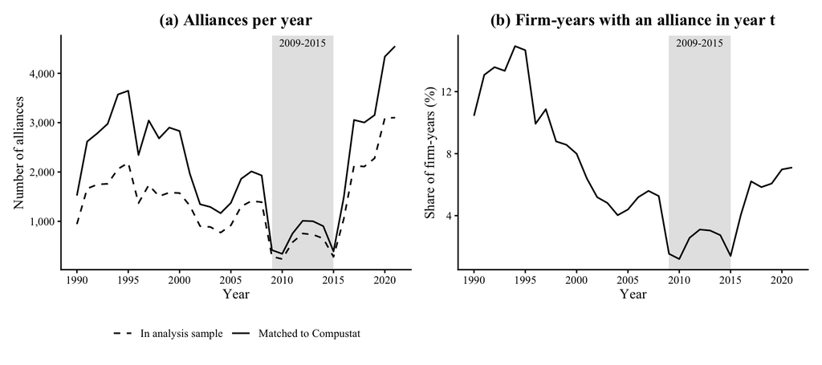

```r
per_year <- rbind(
  af[,   .(n = uniqueN(deal)), by = year][, series := "Matched to Compustat"],
  af_s[, .(n = uniqueN(deal)), by = year][, series := "In analysis sample"])
per_year <- per_year[year %between% c(1990, 2021)]

intensity <- d[, .(firm_years = .N, share = 100 * mean(n_alliances > 0)),
               by = fyear][order(fyear)]

gap <- annotate("rect", xmin = 2009, xmax = 2015, ymin = -Inf, ymax = Inf,
                fill = "grey85", alpha = 0.7)
gap_lab <- annotate("text", x = 2012, y = Inf, label = "2009-2015", vjust = 1.5,
                    family = "Times New Roman", size = 3)

p_a <- ggplot(per_year, aes(x = year, y = n, linetype = series)) +
  gap + gap_lab +
  geom_line(colour = "black", linewidth = 0.6) +
  scale_linetype_manual(values = c("Matched to Compustat" = "solid",
                                   "In analysis sample"   = "dashed")) +
  scale_x_continuous(breaks = seq(1990, 2020, 5)) +
  scale_y_continuous(labels = scales::comma) +
  labs(title = "(a) Alliances per year", x = "Year", y = "Number of alliances",
       linetype = NULL) +
  theme_thesis()

p_b <- ggplot(intensity, aes(x = fyear, y = share)) +
  gap + gap_lab +
  geom_line(colour = "black", linewidth = 0.6) +
  scale_x_continuous(breaks = seq(1990, 2020, 5)) +
  labs(title = "(b) Firm-years with an alliance in year t", x = "Year",
       y = "Share of firm-years (%)") +
  theme_thesis()

fig2 <- p_a + p_b
fig2
```

```r
ggsave(file.path(path, "fig5_alliance_activity.png"), fig2,
       width = 9, height = 4, dpi = 300)

knitr::kable(
  dcast(per_year, year ~ series, value.var = "n")[year %in% 2006:2018],
  caption = "Alliances per year around the coverage gap")
```

Alliances per year around the coverage gap

| year | In analysis sample | Matched to Compustat |
| --- | --- | --- |
| 2006 | 1301 | 1861 |
| 2007 | 1413 | 2012 |
| 2008 | 1389 | 1930 |
| 2009 | 287 | 417 |
| 2010 | 236 | 342 |
| 2011 | 574 | 752 |
| 2012 | 754 | 1011 |
| 2013 | 731 | 1002 |
| 2014 | 653 | 903 |
| 2015 | 280 | 391 |
| 2016 | 1051 | 1485 |
| 2017 | 2128 | 3054 |
| 2018 | 2110 | 3003 |

```r
knitr::kable(intensity[fyear %in% 2006:2018, .(fyear, firm_years, share = round(share, 1))])
```

| fyear | firm_years | share |
| --- | --- | --- |
| 2006 | 16404 | 5.2 |
| 2007 | 17221 | 5.6 |
| 2008 | 17874 | 5.3 |
| 2009 | 18571 | 1.5 |
| 2010 | 19059 | 1.2 |
| 2011 | 19630 | 2.6 |
| 2012 | 19810 | 3.1 |
| 2013 | 20449 | 3.0 |
| 2014 | 20760 | 2.7 |
| 2015 | 20956 | 1.4 |
| 2016 | 21091 | 4.1 |
| 2017 | 21722 | 6.2 |
| 2018 | 22194 | 5.8 |

## 5. Distance categories over time

```r
af_s[, cat_label := factor(cat_labels[category], levels = cat_labels)]
af_s[, period := paste0((year %/% 10) * 10, "s")]

tab <- af_s[, .N, by = .(period, cat_label)]
tab[, share := round(N / sum(N), 3), by = period]
tab_wide <- dcast(tab, cat_label ~ period, value.var = "share")
overall  <- af_s[, .N, by = cat_label][, .(cat_label, all_years = round(N / sum(N), 3))]
tab_wide <- overall[tab_wide, on = "cat_label"]
knitr::kable(tab_wide, caption = "Share of each distance category, overall and per decade")
```

Share of each distance category, overall and per decade

| cat_label | all_years | 1990s | 2000s | 2010s | 2020s |
| --- | --- | --- | --- | --- | --- |
| D0 same 4-digit SIC | 0.130 | 0.136 | 0.150 | 0.123 | 0.093 |
| D1 same 3-digit SIC | 0.129 | 0.110 | 0.146 | 0.129 | 0.152 |
| D2 same major group | 0.081 | 0.085 | 0.088 | 0.079 | 0.064 |
| D3 same division | 0.171 | 0.198 | 0.159 | 0.156 | 0.150 |
| D4 different division | 0.488 | 0.471 | 0.457 | 0.514 | 0.541 |

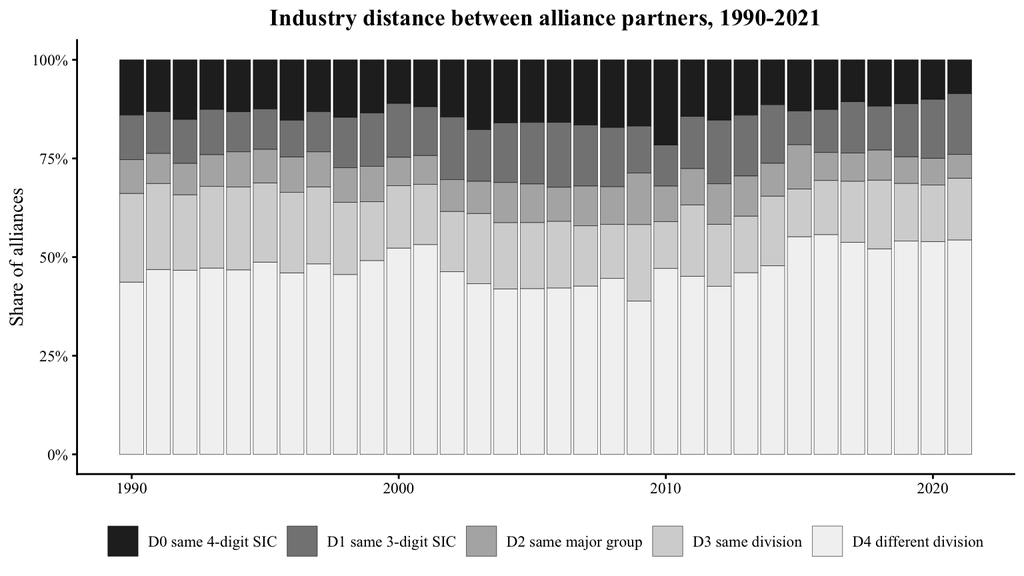

```r
fwrite(tab_wide, file.path(path, "table_distance_by_decade.csv"))

p_dist <- ggplot(af_s[, .N, by = .(year, cat_label)],
                 aes(x = year, y = N, fill = cat_label)) +
  geom_col(position = "fill", width = 0.9, colour = "black", linewidth = 0.1) +
  scale_y_continuous(labels = scales::percent) +
  scale_fill_grey(start = 0.15, end = 0.95) +
  labs(x = NULL, y = "Share of alliances", fill = NULL,
       title = "Industry distance between alliance partners, 1990-2021") +
  theme_thesis()
p_dist
```

```r
ggsave(file.path(path, "fig_distance_by_year.png"), p_dist,
       width = 8, height = 4.5, dpi = 300)
```

## 6. Correlations of the regression variables (Table 4, continued)

```r
cor_vars <- c(growth_f3_w         = "Growth t to t+3",
              growth_l1_w         = "Past growth",
              ln_at_usd           = "Size",
              roa_w               = "ROA",
              leverage_w          = "Leverage",
              n_alliances_3y      = "All alliances",
              n_rel_3y            = "RA",
              n_unrel_3y          = "UA",
              n_jv_3y             = "EQ",
              n_ca_3y             = "NE",
              d0_same4_3y         = "D0",
              d1_same3_3y         = "D1",
              d2_same2_3y         = "D2",
              d3_same_division_3y = "D3",
              d4_diff_division_3y = "D4")

cm <- cor(d[, names(cor_vars), with = FALSE])
dimnames(cm) <- list(cor_vars, cor_vars)

cm_tab <- round(cm, 2)
cm_tab[upper.tri(cm_tab)] <- NA        # lower triangle only
knitr::kable(cm_tab)
```

|  | Growth t to t+3 | Past growth | Size | ROA | Leverage | All alliances | RA | UA | EQ | NE | D0 | D1 | D2 | D3 | D4 |
| --- | --- | --- | --- | --- | --- | --- | --- | --- | --- | --- | --- | --- | --- | --- | --- |
| Growth t to t+3 | 1.00 | NA | NA | NA | NA | NA | NA | NA | NA | NA | NA | NA | NA | NA | NA |
| Past growth | 0.07 | 1.00 | NA | NA | NA | NA | NA | NA | NA | NA | NA | NA | NA | NA | NA |
| Size | -0.01 | -0.04 | 1.00 | NA | NA | NA | NA | NA | NA | NA | NA | NA | NA | NA | NA |
| ROA | 0.11 | 0.02 | 0.13 | 1.00 | NA | NA | NA | NA | NA | NA | NA | NA | NA | NA | NA |
| Leverage | -0.07 | -0.03 | 0.15 | -0.29 | 1.00 | NA | NA | NA | NA | NA | NA | NA | NA | NA | NA |
| All alliances | 0.00 | 0.00 | 0.19 | 0.00 | 0.03 | 1.00 | NA | NA | NA | NA | NA | NA | NA | NA | NA |
| RA | 0.01 | 0.01 | 0.18 | 0.00 | 0.02 | 0.92 | 1.00 | NA | NA | NA | NA | NA | NA | NA | NA |
| UA | 0.00 | 0.00 | 0.18 | 0.00 | 0.03 | 0.94 | 0.72 | 1.00 | NA | NA | NA | NA | NA | NA | NA |
| EQ | 0.00 | -0.01 | 0.18 | 0.01 | 0.04 | 0.68 | 0.62 | 0.65 | 1.00 | NA | NA | NA | NA | NA | NA |
| NE | 0.01 | 0.01 | 0.17 | 0.00 | 0.02 | 0.98 | 0.90 | 0.91 | 0.50 | 1.00 | NA | NA | NA | NA | NA |
| D0 | 0.01 | 0.01 | 0.13 | 0.01 | 0.01 | 0.55 | 0.66 | 0.39 | 0.28 | 0.57 | 1.00 | NA | NA | NA | NA |
| D1 | 0.01 | 0.02 | 0.10 | -0.01 | 0.00 | 0.71 | 0.75 | 0.58 | 0.32 | 0.74 | 0.40 | 1.00 | NA | NA | NA |
| D2 | 0.00 | 0.00 | 0.13 | 0.00 | 0.03 | 0.46 | 0.53 | 0.34 | 0.46 | 0.41 | 0.14 | 0.16 | 1.00 | NA | NA |
| D3 | 0.00 | 0.00 | 0.14 | 0.00 | 0.03 | 0.75 | 0.78 | 0.63 | 0.65 | 0.70 | 0.24 | 0.39 | 0.41 | 1.00 | NA |
| D4 | 0.00 | 0.00 | 0.18 | 0.00 | 0.03 | 0.94 | 0.72 | 1.00 | 0.65 | 0.91 | 0.39 | 0.58 | 0.34 | 0.63 | 1 |

```r
fwrite(as.data.table(cm_tab, keep.rownames = "variable"),
       file.path(path, "table_correlations.csv"))

idx  <- which(abs(cm) >= 0.5 & upper.tri(cm), arr.ind = TRUE)
knitr::kable(
  data.table(var1 = rownames(cm)[idx[, 1]], var2 = colnames(cm)[idx[, 2]],
             r = round(cm[idx], 2))[order(-abs(r))],
  caption = "Pairs with |r| >= 0.5")
```

Pairs with |r| >= 0.5

| var1 | var2 | r |
| --- | --- | --- |
| UA | D4 | 1.00 |
| All alliances | NE | 0.98 |
| All alliances | UA | 0.94 |
| All alliances | D4 | 0.94 |
| All alliances | RA | 0.92 |
| UA | NE | 0.91 |
| NE | D4 | 0.91 |
| RA | NE | 0.90 |
| RA | D3 | 0.78 |
| RA | D1 | 0.75 |
| All alliances | D3 | 0.75 |
| NE | D1 | 0.74 |
| RA | UA | 0.72 |
| RA | D4 | 0.72 |
| All alliances | D1 | 0.71 |
| NE | D3 | 0.70 |
| All alliances | EQ | 0.68 |
| RA | D0 | 0.66 |
| UA | EQ | 0.65 |
| EQ | D3 | 0.65 |
| EQ | D4 | 0.65 |
| UA | D3 | 0.63 |
| D3 | D4 | 0.63 |
| RA | EQ | 0.62 |
| UA | D1 | 0.58 |
| D1 | D4 | 0.58 |
| NE | D0 | 0.57 |
| All alliances | D0 | 0.55 |
| RA | D2 | 0.53 |
| EQ | NE | 0.50 |

How to read the correlations: the total number of alliances is the sum of the five categories, so it is strongly correlated with them by construction. The total is therefore **never** used in the same model as the five categories. The five categories among each other are only moderately correlated, so all five can enter one model.

## 7. Supplementary data checks (referenced in sections 3.2 and 3.3)

### NAICS as an alternative industry classification (focal firms)

```r
fp <- readRDS(file.path(path, "firmyear_panel.rds"))
fp[, naics_chr := as.character(naicsh)]
fp[naics_chr == "", naics_chr := NA]

cov <- fp[, .(share = round(mean(!is.na(naics_chr)), 2)), by = .(fyear, source)]
knitr::kable(dcast(cov, fyear ~ source, value.var = "share")[fyear %in% seq(1990, 2020, 5)],
             caption = "Share of firm-years with a NAICS code")
```

Share of firm-years with a NAICS code

| fyear | Global | NA |
| --- | --- | --- |
| 1990 | 0.76 | 1.00 |
| 1995 | 0.66 | 1.00 |
| 2000 | 0.68 | 1.00 |
| 2005 | 0.88 | 0.99 |
| 2010 | 0.98 | 0.87 |
| 2015 | 0.94 | 0.89 |
| 2020 | 0.82 | 0.85 |

```r
knitr::kable(fp[!is.na(naics_chr), .N, by = .(source, digits = nchar(naics_chr))][order(source, digits)],
             caption = "Number of digits of the NAICS codes")
```

Number of digits of the NAICS codes

| source | digits | N |
| --- | --- | --- |
| Global | 2 | 4063 |
| Global | 3 | 77207 |
| Global | 4 | 126076 |
| Global | 5 | 21584 |
| Global | 6 | 459820 |
| NA | 2 | 221 |
| NA | 3 | 6248 |
| NA | 4 | 9305 |
| NA | 5 | 6024 |
| NA | 6 | 285036 |

```r
d[, .(naics = round(mean(!is.na(naicsh)), 3), sic = round(mean(!is.na(sic2)), 3))]
```

```
   naics   sic
   <num> <num>
1: 0.953     1
```

### NAICS: alliances where both partners have a code (robustness basis)

```r
both_deals <- af[, .N, by = deal][N == 2, deal]
pg    <- af[deal %in% both_deals, .(deal, gvkey, year)]
pairs <- pg[pg, on = .(deal, year), allow.cartesian = TRUE][
  gvkey != i.gvkey, .(deal, year, gvkey, partner_gvkey = i.gvkey)]

nai <- fp[, .(gvkey, fyear, naicsh)]
pairs[nai, on = .(gvkey, year = fyear), focal_naics := i.naicsh]
pairs[nai, on = .(partner_gvkey = gvkey, year = fyear), partner_naics := i.naicsh]

af_s[pairs, on = .(deal, gvkey), `:=`(partner_in_cs = TRUE,
                                      both_naics = !is.na(i.focal_naics) & !is.na(i.partner_naics))]
af_s[is.na(partner_in_cs), `:=`(partner_in_cs = FALSE, both_naics = FALSE)]

af_s[, .(obs = .N,
         partner_in_compustat = round(mean(partner_in_cs), 3),
         both_have_naics      = round(mean(both_naics), 3))]
```

```
     obs partner_in_compustat both_have_naics
   <int>                <num>           <num>
1: 51563                0.426           0.406
```

### Segment data (diversification control not used)

```r
seg <- fread(file.path(path, "segments.csv"))
seg[, gvkey := sprintf("%06d", as.integer(gvkey))]
seg[, dd := as.Date(datadate)]
seg[, fyear := fifelse(month(dd) >= 6, year(dd), year(dd) - 1L)]

seg_ids <- unique(seg[, .(gvkey, fyear)])
d[, has_seg := FALSE]
d[seg_ids, on = .(gvkey, fyear), has_seg := TRUE]
knitr::kable(d[, .(firm_years = .N, with_segments = round(mean(has_seg), 3)), by = source])
```

| source | firm_years | with_segments |
| --- | --- | --- |
| NA | 103373 | 0.890 |
| Global | 358509 | 0.018 |

Compustat segment data cover North America only (89.0% of North American firm-years vs. 1.8% of Global firm-years). A Herfindahl or entropy control would therefore restrict the sample to roughly a fifth of the observations and remove its international character.